# 02 Uvod v Python

## Python

- Splošno namenski visoko nivojski programski jezik.
- Poudarek na berljivosti in preglednosti.
- Podpira različne stile programiranja: *objektno-orientirano*, *imperativno* in *funkcijsko*.
- Guido van Rossum, konec 1980-ih let.
- Odprta koda.
- Python 2.0 leta 2000. Python 2.7 se uporablja v veliko produkcijskih sistemih.
- Python 3.0 leta 2008. Danes: Python 3.4.x
- Vključuje: dinamično tipiziranje, avtomatično čiščenje spomina (ang. garbage collector), veliko znanstvenih knjižnic, …

## Namestitev in okolje IDLE

- Osnovno delovno okolje IDLE je že vključeno v namestitev.
- [Namestitev Pythona 3.1 v Windows XP](http://www.nauk.si/materials/87/out/index.html#state=2)
- [Namestitev in uporaba okolja IDLE](http://www.nauk.si/materials/637/out/index.html#state=2)
- Povezave na naslovih vodijo do animacij.

## Osnovni tipi/razredi in objekti

- Vsak podatek v Pythonu je objekt.
- *Objekt* združuje podatke (atribute) in operacije (metode) nad njim.
- Tip objekta določa *razred* objekta (definicija/tip objekta).
- Osnovni tipi:
  - `int` - celo število (`1`, `1023`).
  - `float` - realno število (`2.1`, `1.1e10`, `1e-3`)
  - `bool` - logična vrednost (`True` ali `False`).
  - `str` - niz - zaporedje znakov v enojnih ali dvojnih narekovajih (`"niz niz"`, `'niz'`, `"'niz'"`, `'niz\nniz'`).

## [Osnovni tipi](http://www.nauk.si/materials/636/out/index.html#state=2)

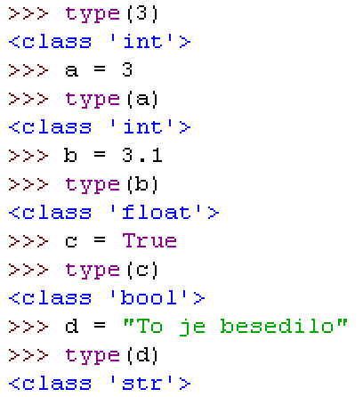

## Osnovni tipi in pretvorbe (`int`)

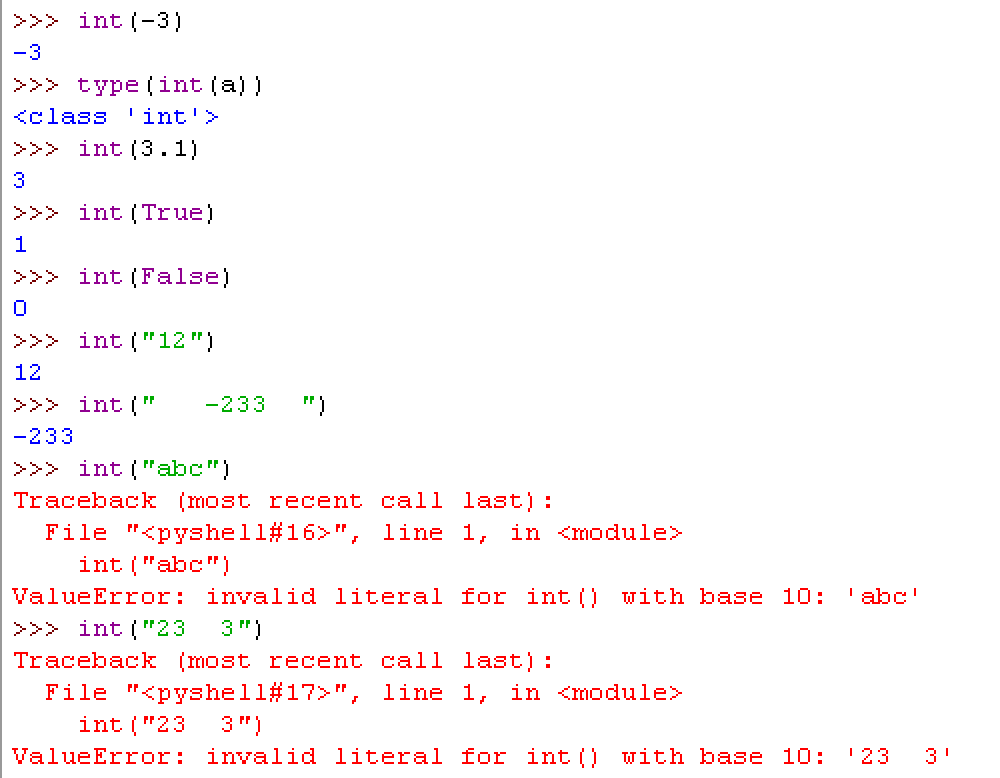

## Osnovni tipi in pretvorbe (`float`)

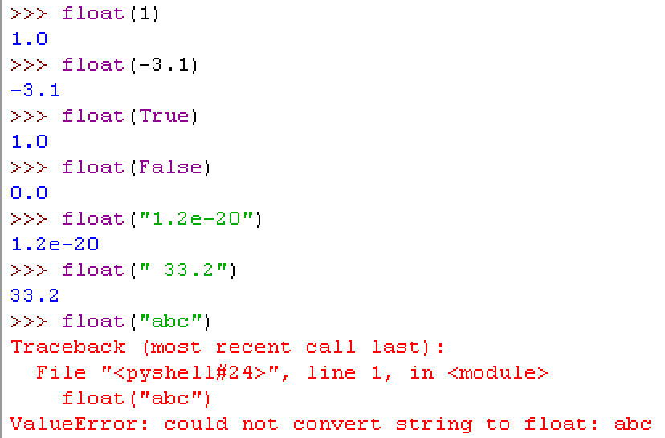

## Osnovni tipi in pretvorbe (`bool`)

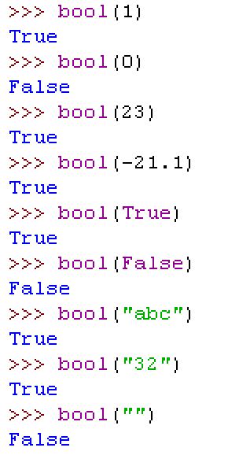

## Osnovni tipi in pretvorbe (`str`)

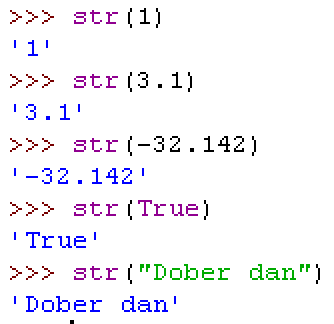

## [Objekti, metode, notranje spremenljivke (atributi) in lastnosti](http://www.nauk.si/materials/638/out/index.html#state=2)

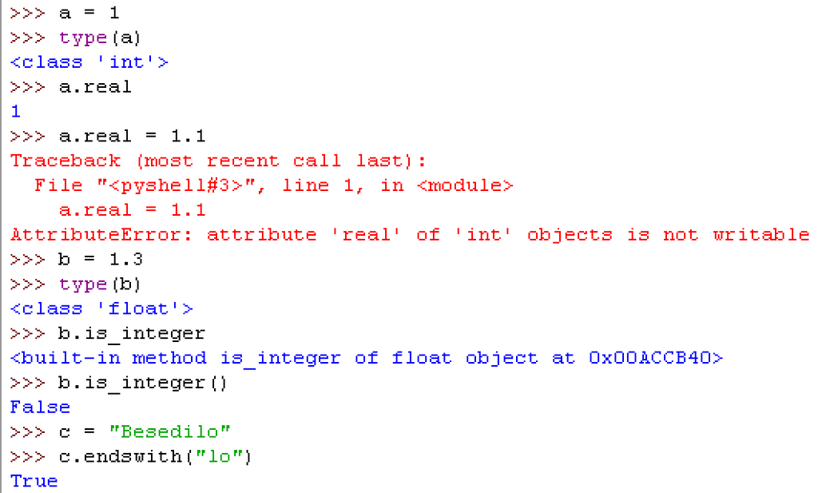

## [Cela števila (`int`) in aritmetične operacije](http://www.nauk.si/materials/641/out/index.html#state=2)

- Osnovni aritmetični operatorji:
  - `+` (vsota)
  - `-` (razlika)
  - `*` (produkt)
  - `**` (potenca)
  - `/` (količnik, v realnih številih)
  - `//` (celi del količnika)
  - `%` (ostanek pri celoštevilskem deljenju)

## Cela števila (`int`) in aritmetične operacije

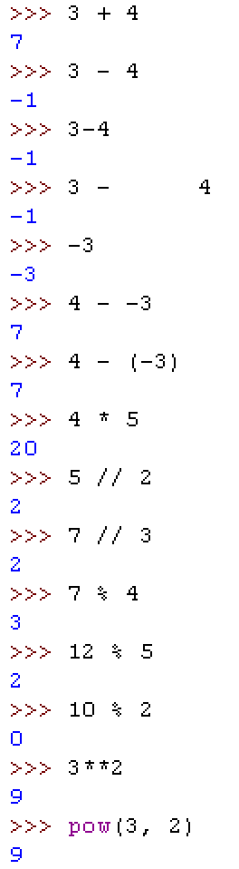

## Cela števila (`int`) in aritmetične operacije

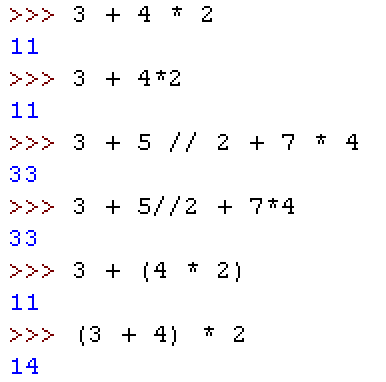

## [Realna števila (`float`)](http://www.nauk.si/materials/731/out/index.html#state=2)

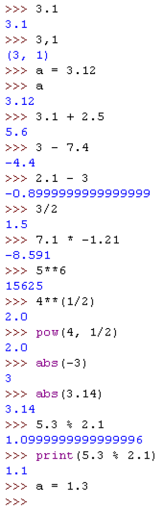

## Realna števila (`float`)

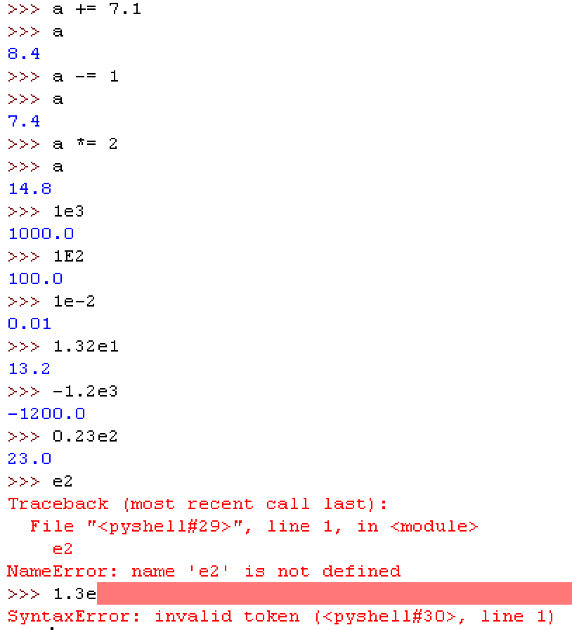

## [Kompleksna števila](http://www.nauk.si/materials/696/out/index.html#state=2)

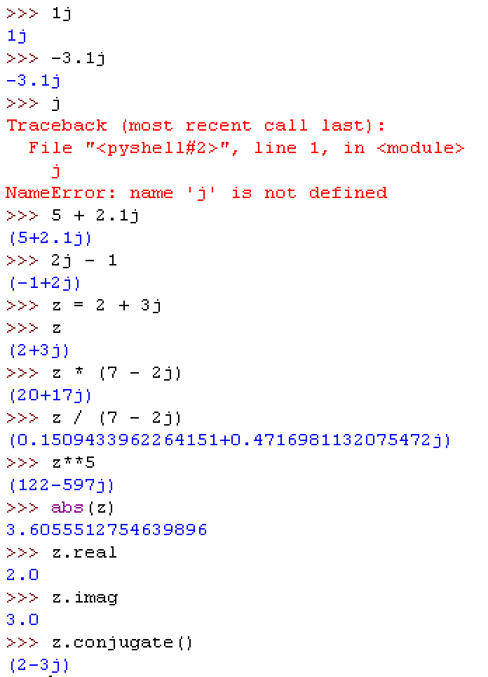

## [Nizi](http://www.nauk.si/materials/724/out/index.html#state=2)

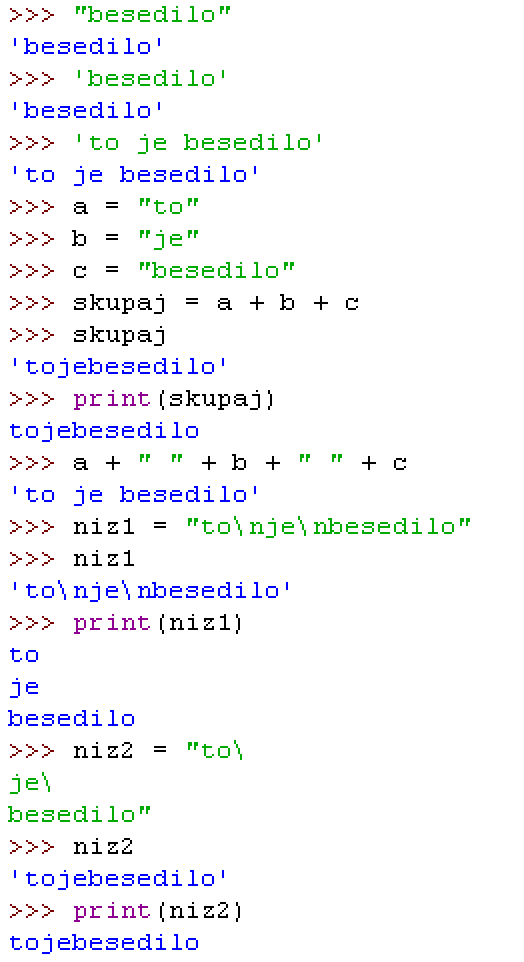

## Nizi

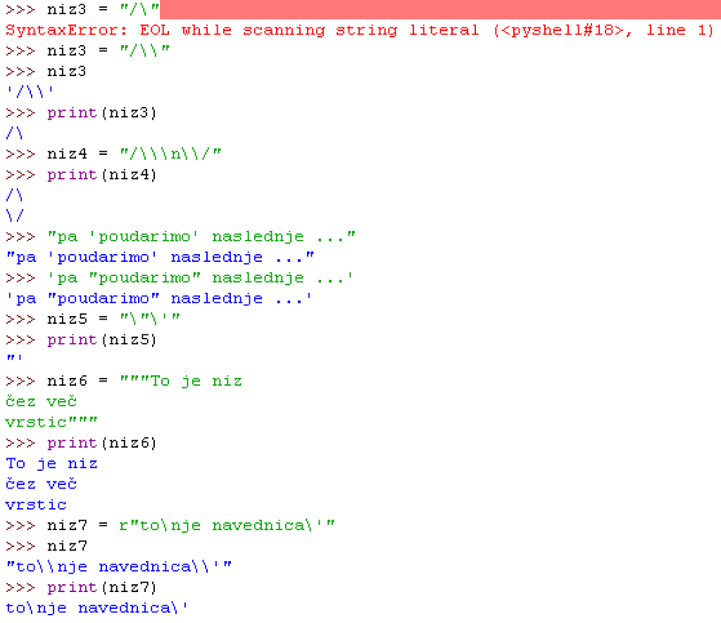

## [Logične vrednosti in logični operatorji](http://www.nauk.si/materials/705/out/index.html#state=2)

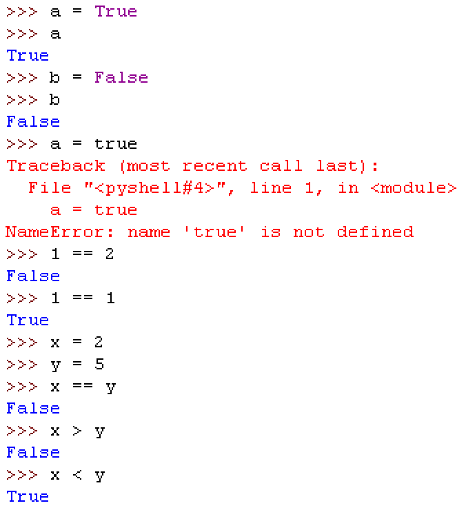

## Logične vrednosti in logični operatorji

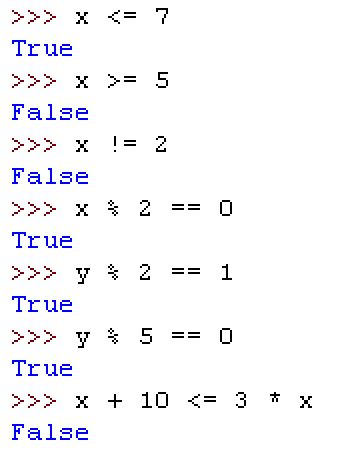

## [Sestavljeni logični izrazi](http://www.nauk.si/materials/706/out/index.html#state=1)

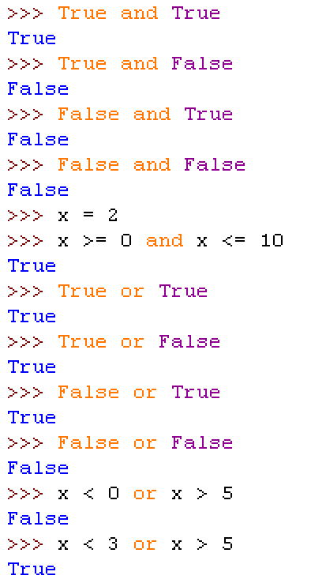

## Sestavljeni logični izrazi

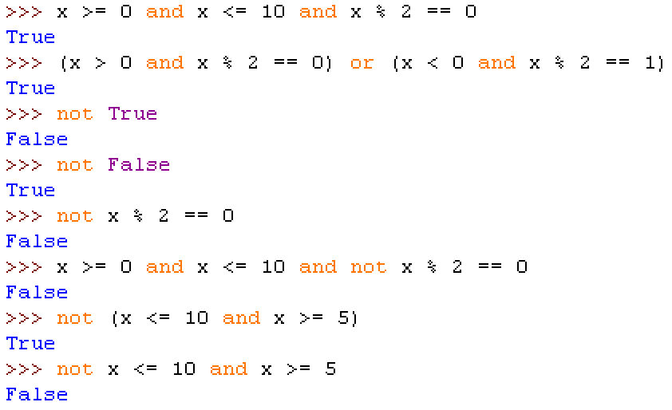

## [Spremenljivke](http://www.nauk.si/materials/640/out/index.html#state=2)

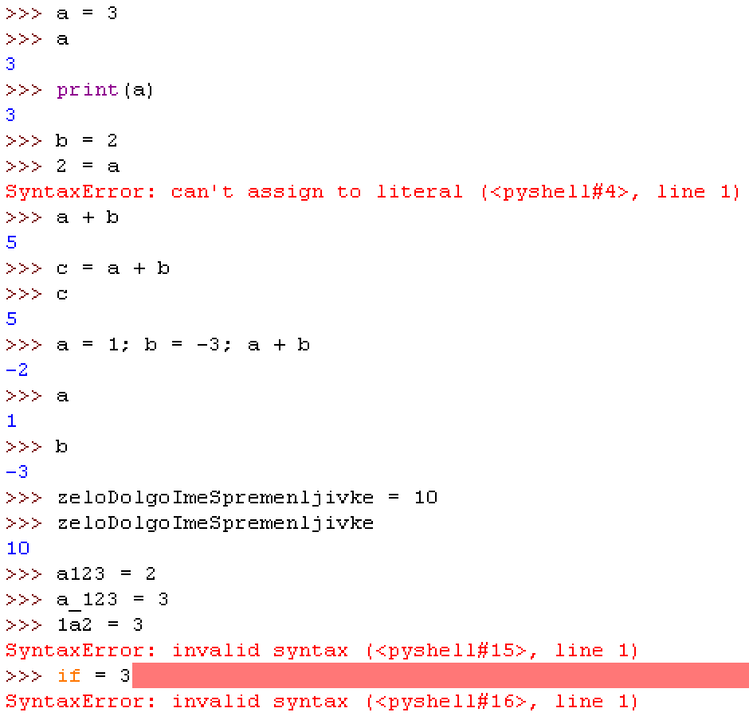

## Spremenljivke

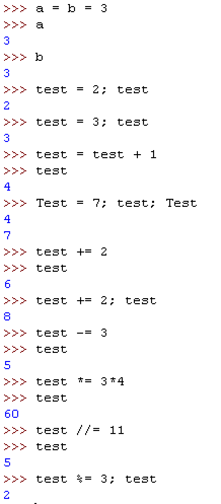

## [Moduli in modul `math`](http://www.nauk.si/materials/697/out/index.html#state=1)

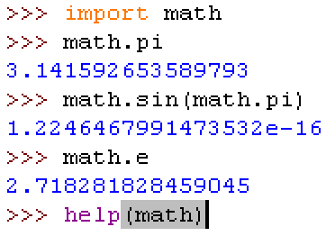

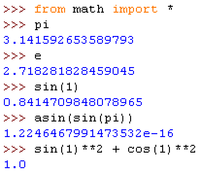

## Modul `math`

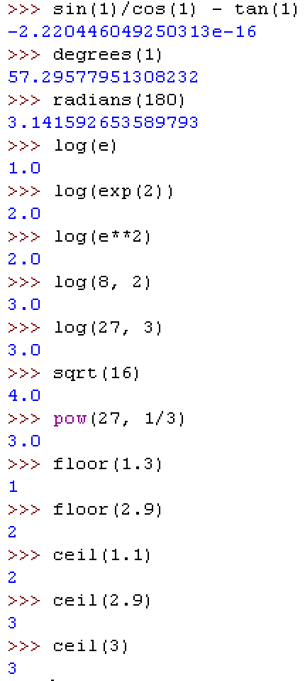

## [Primer: Določanje števk števila](http://www.nauk.si/materials/692/out/index.html#state=2)

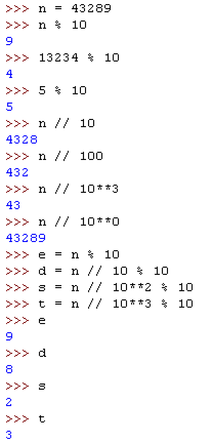

## [Primer: Sestavljanje števila iz števk)](http://www.nauk.si/materials/694/out/index.html#state=2)

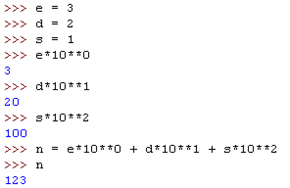

## [Primer: Pretvorba yardov v metre, decimetre…](http://www.nauk.si/materials/695/out/index.html#state=2)

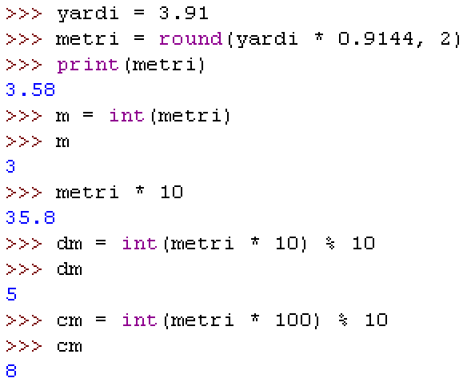

## [Izpisovanje na zaslon](http://www.nauk.si/materials/704/out/index.html#state=2)

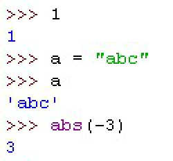

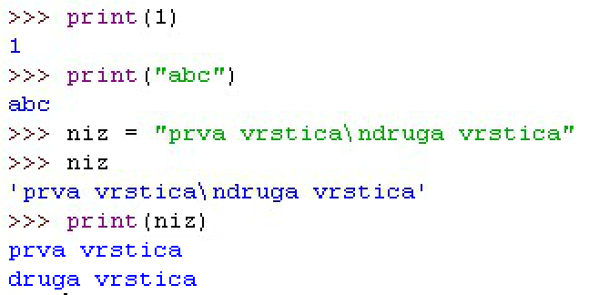